# An Objective Approach for Categorizing Staff Bassed on Their vulnerabulity to Fatigue

Ashish Gupta[^1]

Fadel M. Megahed[^2]

Lora A. Cavuoto[^3]

Hamidreza Ahady Dolatsara[^4]

September 27, 2018

A major goal of this study is developing an objective measure for understanding perceived level of fatigue using IoT data. Therefore, it enables investigation of fatigue without interfering with routine tasks or interrupting the workers. Use of IoT devices for capturing activity data provides an objective measure for assessing injury risk or fatigue-levels of an employee. This could eventually lead to better assigning for job routines based on the individual performance.

# 1 Loading prerequisites: Data & Libraries

In the following block, required *R* libraries are checked for existance and then installed if it’s needed.

```r
rm(list = ls()) # clears global environment (functions and variables)
graphics.off() # clears graphics
if(!("pacman" %in% rownames(installed.packages()))){install.packages("pacman")}# pacman would be installed if it's not existed
library(pacman)
p_load(caret, rio, dtwclust, graph, RBGL, arules, stringr, pROC, DT)
```

Object oriented programming is employed for this project. In this approach of programming, an empty object is created then in each step some attributes and data would be added to the object. Each step is basically a function that perform some processes over the object.Th following snippet is designed to define the functions.

defining functions and loading the required libraries

```r
# a function for calculating RUS sample balancing
seed_no<-123
top_alg<-3
RUS_func <- function(input_data){

  Train_Two <- input_data[ which(as.character(input_data$TARGET)=="two"), ]
  Train_One <- input_data[ which(as.character(input_data$TARGET)=="one"), ]
  if(nrow(Train_Two)<=nrow(Train_One)){
    sample_size<-nrow(Train_Two)
    Train_One<-Train_One[sample(nrow(Train_One), sample_size), ]
  }else{
    sample_size<-nrow(Train_One)
    Train_Two<-Train_Two[sample(nrow(Train_Two), sample_size), ]
  }
  input_data<-rbind(Train_One,Train_Two)

  return(input_data)
}

###########
# it exracts importance of features in a prediction
model_imp_exc <- function(input_object,vars_org){
  imp_model<-varImp(input_object)
  imp_model<-as.data.frame(imp_model$importance)
  imp_model$variables<-rownames(imp_model)
  imp_model$importance<-as.numeric(imp_model[,1])

  model_imp<-matrix(0, ncol = 1, nrow = nrow(imp_model))
  model_imp<-as.data.frame(model_imp)


  model_imp$variables<-imp_model$variables
  model_imp$importance<-imp_model$importance
  model_imp$V1<-NULL

  seeker<-model_imp
  seeker$real_name<-NA

  seeked<-as.data.frame(vars_org[,1])
  names(seeked)<-"variables"

  for (i in 1:nrow(seeker)){
    for (j in 1:nrow(seeked)) {
      if(grepl(seeked$variables[j],seeker$variables[i])){
        if(str_count(seeker$variables[i],"_")==str_count(seeked$variables[j],"_")){
          seeker$real_name[i]<-as.character(seeked$variables[j])}
      }
    }
  }
  # It's for the variables that created by us and are not in the original dataset
  for (i in 1:nrow(seeker)){
    if(is.na(seeker$real_name[i])){seeker$real_name[i]<-seeker$variables[i]}
  }
  str(seeker$importance)
  seeker<-seeker[c("variables","importance")]

  return(seeker)
}
###########
# it a minor function gets the output of model_imp_exc() function and change its format to a dataframe
matrix_filler_2<-function(col_no,filling_matrix,filler_matrix,common_col){
  common_col<-paste(common_col,"_",col_no,sep="")

  for(j in filler_matrix$variables){
    filling_matrix[j,common_col]<-filler_matrix$importance[which(filler_matrix$variables==j)]
  }

  return(filling_matrix)
}
###########
# a function for calculating accuracy of a prediction model (e.g. svm, logistics, ranfopm forrest,...)
accuracy_cal<-function(actual,predicted){
  counter<-0
  for(i in 1:length(actual)){
    if(actual[i]==predicted[i]){counter<-counter+1}
  }
  percent_accuracy<-round((counter/length(actual)),2)
  return(percent_accuracy)
}

###########################################
# this function gets the raw data and change its format to a suitable format for clustering
# the inputs are the raw data , different start time (1st to 9th data points). min_all is the last data points that all of earlier data points are not NAs
prepar<-function(data,start_t,min_all){

  for(i in 1:15){

      data[["time_series"]][["table_ID11"]][[i]]<-as.numeric(data[["subjects"]][[paste("subject",i,sep="")]]["ID11",(start_t:min_all)])
      data[["time_series"]][["table_ID13"]][[i]]<-as.numeric(data[["subjects"]][[paste("subject",i,sep="")]]["ID13",(start_t:min_all)])
      data[["time_series"]][["table_ID19"]][[i]]<-as.numeric(data[["subjects"]][[paste("subject",i,sep="")]]["ID19",(start_t:min_all)])
      data[["time_series"]][["table_ID20"]][[i]]<-as.numeric(data[["subjects"]][[paste("subject",i,sep="")]]["ID20",(start_t:min_all)])
      data[["time_series"]][["table_ID7"]][[i]]<-as.numeric(data[["subjects"]][[paste("subject",i,sep="")]]["ID7",(start_t:min_all)])
  }

  # now, I make a table of observations for the variables
  template<-matrix(0, ncol = 86, nrow = 15)
  template<-as.data.frame(template)
  template$V1<-c(1:15)
  names(template)<-c("subjects",paste("ts",1:85,sep=""))

  data_table_ID11<-do.call(rbind.data.frame, data$time_series$table_ID11)
    names(data_table_ID11)<-c(paste("ts",start_t:50,sep=""))
    data_table_ID11$subjects<-rownames(data_table_ID11)
  data_table_ID13<-do.call(rbind.data.frame, data$time_series$table_ID13)
      names(data_table_ID13)<-c(paste("ts",start_t:50,sep=""))
      data_table_ID13$subjects<-rownames(data_table_ID13)
  data_table_ID19<-do.call(rbind.data.frame, data$time_series$table_ID19)
      names(data_table_ID19)<-c(paste("ts",start_t:50,sep=""))
      data_table_ID19$subjects<-rownames(data_table_ID19)
  data_table_ID20<-do.call(rbind.data.frame, data$time_series$table_ID20)
      names(data_table_ID20)<-c(paste("ts",start_t:50,sep=""))
      data_table_ID20$subjects<-rownames(data_table_ID20)
  data_table_ID7<-do.call(rbind.data.frame, data$time_series$table_ID7)
      names(data_table_ID7)<-c(paste("ts",start_t:50,sep=""))
      data_table_ID7$subjects<-rownames(data_table_ID7)

    data_table_ID3.4.5.6<-template[,1:2]
  data_table_ID3.4.5.6$ts1<-NULL

  # recording gender age weight height of subject which is same in all of time points

  for(i in 1:15){
    data_table_ID3.4.5.6[i,"ID3"]<-as.numeric(data[["subjects"]][[paste("subject",i,sep="")]]["ID3",1])
    data_table_ID3.4.5.6[i,"ID4"]<-as.numeric(data[["subjects"]][[paste("subject",i,sep="")]]["ID4",1])
    data_table_ID3.4.5.6[i,"ID5"]<-as.numeric(data[["subjects"]][[paste("subject",i,sep="")]]["ID5",1])
    data_table_ID3.4.5.6[i,"ID6"]<-as.numeric(data[["subjects"]][[paste("subject",i,sep="")]]["ID6",1])
      }

  data$data_table_ID11<-data_table_ID11
  data$data_table_ID13<-data_table_ID13
  data$data_table_ID19<-data_table_ID19
  data$data_table_ID20<-data_table_ID20
  data$data_table_ID7<-data_table_ID7

  data$data_table_ID3.4.5.6<-data_table_ID3.4.5.6

  return(data)

}

###########################################
# a function for clustering time series. its inputs are data object (has time series of Borg and sensors), centroid and distance parameters for clustering
clusterer<-function(data_obj,centr_par,dis_par){
acf_fun <- function(dat, ...) {lapply(dat, function(x) as.numeric(acf(x, lag.max = 100L, plot = FALSE)$acf))}

  for(i in c(7,11,13,19,20)){
  assign(paste("clust_part_ID",i,sep="") ,dtwclust::tsclust(data_obj[["time_series"]][[paste("table_ID",i,sep="")]], k = 2L,
                                          distance = dis_par, centroid = centr_par,
                                          seed = seed_no, trace = TRUE,
                                          control = partitional_control(pam.precompute = FALSE),
                                          args = tsclust_args(dist = list(window.size = 2L)))
                                          )
```

```r
  }
#flipper input change
temp11<-flipper(data_obj$data_table_ID11,clust_part_ID11@cluster,"low")
data_obj$data_table_ID3.4.5.6[paste(centr_par,dis_par,"11",sep="_")]<-temp11

temp13<-flipper(data_obj$data_table_ID13,clust_part_ID13@cluster,"low")
data_obj$data_table_ID3.4.5.6[paste(centr_par,dis_par,"13",sep="_")]<-temp13

temp19<-flipper(data_obj$data_table_ID19,clust_part_ID19@cluster,"low")
data_obj$data_table_ID3.4.5.6[paste(centr_par,dis_par,"19",sep="_")]<-temp19

temp20<-flipper(data_obj$data_table_ID20,clust_part_ID20@cluster,"high")
data_obj$data_table_ID3.4.5.6[paste(centr_par,dis_par,"20",sep="_")]<-temp20

temp7<-flipper(data_obj$data_table_ID7,clust_part_ID7@cluster,"low")
data_obj$data_table_ID3.4.5.6[paste(centr_par,dis_par,"7",sep="_")]<-temp7

#it's for taking care of NAs
if(is.na(table(temp11)[1])){clust11_freq_1<-0}else{clust11_freq_1<-table(temp11)[1]}
if(is.na(table(temp11)[2])){clust11_freq_2<-0}else{clust11_freq_2<-table(temp11)[2]}

if(is.na(table(temp13)[1])){clust13_freq_1<-0}else{clust13_freq_1<-table(temp13)[1]}
if(is.na(table(temp13)[2])){clust13_freq_2<-0}else{clust13_freq_2<-table(temp13)[2]}

if(is.na(table(temp19)[1])){clust19_freq_1<-0}else{clust19_freq_1<-table(temp19)[1]}
if(is.na(table(temp19)[2])){clust19_freq_2<-0}else{clust19_freq_2<-table(temp19)[2]}

if(is.na(table(temp20)[1])){clust20_freq_1<-0}else{clust20_freq_1<-table(temp19)[1]}
if(is.na(table(temp20)[2])){clust20_freq_2<-0}else{clust20_freq_2<-table(temp19)[2]}

if(is.na(table(temp7)[1])){clust7_freq_1<-0}else{clust7_freq_1<-table(temp7)[1]}
if(is.na(table(temp7)[2])){clust7_freq_2<-0}else{clust7_freq_2<-table(temp7)[2]}


clus11<-abs(clust11_freq_1-clust11_freq_2)
clus13<-abs(clust13_freq_1-clust13_freq_2)
clus19<-abs(clust19_freq_1-clust19_freq_2)
clus20<-abs(clust20_freq_1-clust20_freq_2)
clus7<-abs(clust7_freq_1-clust7_freq_2)


max_cluss<-max(clus11,clus13,clus19,clus20,clus7)

data_obj$max_cluss<-max_cluss

return(data_obj)

}
##################
# this is a sub function undert the clusterer() function. It basically take care of the definition of clusters' labels. In (Borg's rate, step_time_SD,step_distance_SD, and step_peak_jrk_average) higher values associated to higher fatigues' levels however in step_peak_jrk_average, the lower values is associated to higher fatigue. It just flips the step_peak_jrk_average value so for the flipped version cluster label of 1 means lower fatigue level, and 2 means higher level of fatigue which is same as other clusters' labels made by other variables
 flipper<-function(data_series,data_clust,cluss_one){

   min_1<-0
   min_2<-0
   work_1<-sum(which(data_clust==1))
   work_2<-sum(which(data_clust==2))
   i<-1

   if(work_1*work_2>0){
     for(i in which(data_clust==1)){
       min_1<- min_1+mean(as.numeric(data_series[i,1:(ncol(data_series)-1)]))}
     for(j in which(data_clust==2)){
       min_2<- min_2+mean(as.numeric(data_series[j,1:(ncol(data_series)-1)]))}

     min_1<-min_1/length(which(data_clust==1))
     min_2<-min_2/length(which(data_clust==2))
   }



   if(cluss_one=="low" && min_1>min_2){
     temp<-data_clust
     temp[which(data_clust==1)]<-2
     temp[which(data_clust==2)]<-1
     data_clust<-temp
   }
   if(cluss_one=="high" && min_1<min_2){
     temp<-data_clust
     temp[which(data_clust==1)]<-2
     temp[which(data_clust==2)]<-1
     data_clust<-temp
   }
   return(data_clust)

 }
############################################
# it gets input from the clusterer() function and then find diffrences in the members of each clusters and then calculate overlap of sensor data with BOrg's rate in clustering
compare_clus<-function(data_obj){

resul_cluss<-as.data.frame(matrix(0, ncol = 3, nrow = 45))
names(resul_cluss)<-c("dis_par","centr_par","cluss_diff")


clust_ID7<-data_obj$data_table_ID3.4.5.6
clust_ID11<-data_obj$data_table_ID3.4.5.6
clust_ID13<-data_obj$data_table_ID3.4.5.6
clust_ID19<-data_obj$data_table_ID3.4.5.6
clust_ID20<-data_obj$data_table_ID3.4.5.6


row_counter<-0

for(i in c("mean", "median", "shape", "dba", "pam")){
  for(j in c("dtw","dtw2","dtw_basic","dtw_lb","lbk","lbi","sbd","gak","sdtw")){
    row_counter<-row_counter+1
    resul_cluss[row_counter,"dis_par"]<-j
    resul_cluss[row_counter,"centr_par"]<-i
    temp<-clusterer(data_obj,i,j)
    resul_cluss[row_counter,"cluss_diff"]<-temp[["max_cluss"]]
    clust_ID7[[paste(i,j,sep="_")]]<-temp$data_table_ID3.4.5.[,paste(i,j,7,sep="_")]
    clust_ID11[[paste(i,j,sep="_")]]<-temp$data_table_ID3.4.5.[,paste(i,j,11,sep="_")]
    clust_ID13[[paste(i,j,sep="_")]]<-temp$data_table_ID3.4.5.[,paste(i,j,13,sep="_")]
    clust_ID19[[paste(i,j,sep="_")]]<-temp$data_table_ID3.4.5.[,paste(i,j,19,sep="_")]
    clust_ID20[[paste(i,j,sep="_")]]<-temp$data_table_ID3.4.5.[,paste(i,j,20,sep="_")]


    perf_711<-as.data.frame(table(temp$data_table_ID3.4.5.[,paste(i,j,11,sep="_")]*temp$data_table_ID3.4.5.[,paste(i,j,7,sep="_")]))
    perf_713<-as.data.frame(table(temp$data_table_ID3.4.5.[,paste(i,j,13,sep="_")]*temp$data_table_ID3.4.5.[,paste(i,j,7,sep="_")]))
    perf_719<-as.data.frame(table(temp$data_table_ID3.4.5.[,paste(i,j,19,sep="_")]*temp$data_table_ID3.4.5.[,paste(i,j,7,sep="_")]))
    perf_720<-as.data.frame(table(temp$data_table_ID3.4.5.[,paste(i,j,20,sep="_")]*temp$data_table_ID3.4.5.[,paste(i,j,7,sep="_")]))
    perf_7<-as.data.frame(table(temp$data_table_ID3.4.5.[,paste(i,j,7,sep="_")]))
    perf_11<-as.data.frame(table(temp$data_table_ID3.4.5.[,paste(i,j,11,sep="_")]))
    perf_13<-as.data.frame(table(temp$data_table_ID3.4.5.[,paste(i,j,13,sep="_")]))
    perf_19<-as.data.frame(table(temp$data_table_ID3.4.5.[,paste(i,j,19,sep="_")]))
    perf_20<-as.data.frame(table(temp$data_table_ID3.4.5.[,paste(i,j,20,sep="_")]))


      temp7<-length(abs(perf_7[which(perf_7$Var1==1),"Freq"]-perf_7[which(perf_7$Var1==2),"Freq"]))
      if(temp7==0){temp7<-15}else{temp7<-abs(perf_7[which(perf_7$Var1==1),"Freq"]-perf_7[which(perf_7$Var1==2),"Freq"])}
      resul_cluss$diff_7[row_counter]<-temp7
```

```r
      temp11<-length(abs(perf_11[which(perf_11$Var1==1),"Freq"]-perf_11[which(perf_11$Var1==2),"Freq"]))
      if(temp11==0){temp11<-15}else{temp11<-abs(perf_11[which(perf_11$Var1==1),"Freq"]-perf_11[which(perf_11$Var1==2),"Freq"])}
      resul_cluss$diff_11[row_counter]<-temp11

      temp13<-length(abs(perf_13[which(perf_13$Var1==1),"Freq"]-perf_13[which(perf_13$Var1==2),"Freq"]))
      if(temp13==0){temp13<-15}else{temp13<-abs(perf_13[which(perf_13$Var1==1),"Freq"]-perf_13[which(perf_13$Var1==2),"Freq"])}
      resul_cluss$diff_13[row_counter]<-temp13

      temp19<-length(abs(perf_19[which(perf_19$Var1==1),"Freq"]-perf_19[which(perf_19$Var1==2),"Freq"]))
      if(temp19==0){temp19<-15}else{temp19<-abs(perf_19[which(perf_19$Var1==1),"Freq"]-perf_19[which(perf_19$Var1==2),"Freq"])}
      resul_cluss$diff_19[row_counter]<-temp19

      temp20<-length(abs(perf_20[which(perf_20$Var1==1),"Freq"]-perf_20[which(perf_20$Var1==2),"Freq"]))
      if(temp20==0){temp20<-15}else{temp20<-abs(perf_20[which(perf_20$Var1==1),"Freq"]-perf_20[which(perf_20$Var1==2),"Freq"])}
      resul_cluss$diff_20[row_counter]<-temp20


    # resul_cluss$over_711[row_counter]<-max((perf_711[which(perf_711$Var1==1),"Freq"]+perf_711[which(perf_711$Var1==4),"Freq"]),perf_711[which(perf_711$Var1==2),"Freq"])
    # resul_cluss$over_713[row_counter]<-max((perf_713[which(perf_713$Var1==1),"Freq"]+perf_713[which(perf_713$Var1==4),"Freq"]),perf_713[which(perf_713$Var1==2),"Freq"])
    # resul_cluss$over_719[row_counter]<-max((perf_719[which(perf_719$Var1==1),"Freq"]+perf_719[which(perf_719$Var1==4),"Freq"]),perf_719[which(perf_719$Var1==2),"Freq"])
    # resul_cluss$over_720[row_counter]<-max((perf_720[which(perf_720$Var1==1),"Freq"]+perf_720[which(perf_720$Var1==4),"Freq"]),perf_720[which(perf_720$Var1==2),"Freq"])

    # I have to do it to find the overlap because
    if(length(perf_711[which(perf_711$Var1==1),"Freq"])==1){over_711_1<-perf_711[which(perf_711$Var1==1),"Freq"]}else{over_711_1<-0}
    if(length(perf_713[which(perf_713$Var1==1),"Freq"])==1){over_713_1<-perf_713[which(perf_713$Var1==1),"Freq"]}else{over_713_1<-0}
    if(length(perf_719[which(perf_719$Var1==1),"Freq"])==1){over_719_1<-perf_719[which(perf_719$Var1==1),"Freq"]}else{over_719_1<-0}
    if(length(perf_720[which(perf_720$Var1==1),"Freq"])==1){over_720_1<-perf_720[which(perf_720$Var1==1),"Freq"]}else{over_720_1<-0}

    if(length(perf_711[which(perf_711$Var1==4),"Freq"])==1){over_711_4<-perf_711[which(perf_711$Var1==4),"Freq"]}else{over_711_4<-0}
    if(length(perf_713[which(perf_713$Var1==4),"Freq"])==1){over_713_4<-perf_713[which(perf_713$Var1==4),"Freq"]}else{over_713_4<-0}
    if(length(perf_719[which(perf_719$Var1==4),"Freq"])==1){over_719_4<-perf_719[which(perf_719$Var1==4),"Freq"]}else{over_719_4<-0}
    if(length(perf_720[which(perf_720$Var1==4),"Freq"])==1){over_720_4<-perf_720[which(perf_720$Var1==4),"Freq"]}else{over_720_4<-0}

    resul_cluss$over_711[row_counter]<-(over_711_1+over_711_4)
    resul_cluss$over_713[row_counter]<-(over_713_1+over_713_4)
    resul_cluss$over_719[row_counter]<-(over_719_1+over_719_4)
    resul_cluss$over_720[row_counter]<-(over_720_1+over_720_4)
  }
}

data_obj$resul_cluss<-resul_cluss
data_obj$clust_ID7<-clust_ID7
data_obj$clust_ID11<-clust_ID11
data_obj$clust_ID13<-clust_ID13
data_obj$clust_ID19<-clust_ID19
data_obj$clust_ID20<-clust_ID20



return(data_obj)
}
##################

# this function is forone-leave out prediction
  #data: data used in the prediction
  #TARGET: target variable
  #vars<- independent variables
  #ensembler: super learning algorithm in ensembling approach
  #B_alg: sample balancing algorithm (RUS,SMOTE,NONE)
  #cntr_type:specifying "trainControl" in the caret package, for more information check inside of the "leave_out" function
  #method_pred: specifying if it is a regular preduction or an ensemble one
leave_out<-function(data,TARGET,vars,ensembler,B_alg,cntr_type,method_pred){
  #next line is just for finding threshold of prediction
  if(method_pred=="regular"){
    data$TARGET01<-as.numeric(data$TARGET)

    data$TARGET<-as.factor(data$TARGET)
    levels(data$TARGET)[1] <- "one"
    levels(data$TARGET)[2] <- "two"
    }

  data$TARGET<-as.factor(data$TARGET)

  n_rows<-nrow(data)

  library(caret)
  # next library is for discretize function
  library(arules)
  # the following library is for loading strcount in variable importance function
  library(stringr)

  # the following library is for ROC / area under the curve calculation
  library(pROC)

  if(cntr_type=="simple"){
    control_<- trainControl(method = "none",  savePredictions = TRUE,
                            verboseIter = FALSE,returnResamp = "all",classProbs = TRUE)}
  if(cntr_type=="simplegbm"){
    control_<- trainControl(method = "cv", number = 1, savePredictions = TRUE,
                            verboseIter = FALSE,classProbs = TRUE, summaryFunction = twoClassSummary)
  }

  if(cntr_type=="simple_roc"){
    control_<- trainControl(method = "none",  savePredictions = TRUE,
                            verboseIter = FALSE,returnResamp = "all",classProbs = TRUE, summaryFunction = twoClassSummary)}

  if(cntr_type=="repeatedcv_roc"){
    control_<- trainControl(method="repeatedcv", number=2, repeats=5,  savePredictions = TRUE,
                            verboseIter = FALSE,returnResamp = "all",classProbs = TRUE, summaryFunction = twoClassSummary)}

  if(cntr_type=="cv_roc"){
    control_<- trainControl(method = "cv", number = 2, savePredictions = TRUE,
                            verboseIter = FALSE,classProbs = TRUE, summaryFunction = twoClassSummary)}


  resul_prob<-matrix(0, ncol = 8, nrow = n_rows)
  resul_prob<-as.data.frame(resul_prob)
  names(resul_prob) <- c("ID","TARGET","TARGET01","log","svm","rf","nnet","tan")
  resul_prob$TARGET<-data$TARGET
  resul_prob$ID<-rownames(resul_prob)
  resul_prob$TARGET01<-data$TARGET01

  resul_raw<-resul_prob


  resul_svm_imp<-matrix(0, ncol = n_rows, nrow = length(vars))
  resul_svm_imp<-as.data.frame(resul_svm_imp)
  names(resul_svm_imp) <- paste("subject_", 1:n_rows, sep = "")
  rownames(resul_svm_imp)<-vars
```

```r
  resul_rf_imp<-resul_svm_imp
  resul_nnet_imp<-resul_svm_imp
  resul_tan_imp<-resul_svm_imp
  resul_log_imp<-resul_svm_imp

  tan_vars<-vars


  formula_format<-paste("TARGET ~ ",paste(vars, collapse="+"),sep = "")
  formula<-as.formula(formula_format)

  VarsData_Phase<-as.data.frame(vars)
  names(VarsData_Phase)<-"variables"


  major_data<-list()
  all_models<-list()

  # Recording train and test folds
  major_data$data_folded<-data
  #i<-2

  for ( i in 1: n_rows){
    test_data<-data[data$ID == i,]
    train_data<-data[data$ID != i,]

    tt<-as.data.frame(table(train_data$TARGET))
    #table(train_data$TARGET)
    common<-tt$Freq[1]
    rare<-tt$Freq[2]
    k<-1
    if(common<rare){
      temp_<-common
      common<-rare
      rare<-temp_
    }
    if(B_alg=="RUS"){
      train_data<-RUS_func(train_data)
      #table(train_data$TARGET)
      # Recording the row id of RUS data
      # RUS_fold<-paste(c("RUS_id_fold_",i),collapse = "")
      # major_data[[RUS_fold]]<-train_data$id
    }

    if(B_alg=="SMOTE"){
      train_data$TARGET<-as.factor(train_data$TARGET)
      H_por_low<-1
      H_por_high<-1
      H_por_low<-(1/H_por_low)
      H_por_high<-H_por_high*100
      perc_over<-100*(common-rare)/(rare*H_por_low)*k
      perc_under<-100*(1/perc_over)*common
      table(train_data$TARGET)
      row_no<-nrow(train_data)
      smoted_data<-DMwR::SMOTE(TARGET ~ ., train_data, perc.over = perc_over,perc.under = (((perc_over/100)+1)/(perc_over/100))*H_por_high)
      train_data<-smoted_data[complete.cases(smoted_data), ]
    }

    #===================

    if(method_pred=="regular"){
      mod_log <-caret::train(formula,  data=train_data, method="glm", family="binomial",
                             trControl = control_, tuneLength = 5)

      mod_rf<-caret::train(formula,  data=train_data, method="rf",
                           trControl = control_, tuneGrid=expand.grid(mtry = ncol(train_data)-4),
                           tuneLength = 5)

      svm_cost<-.5
      svm_sigma<-.0001


      if(class(try(

      mod_svm<-caret::train(formula,  data=train_data, method="svmRadial", family="binomial",
                            trControl = control_,  tuneGrid=expand.grid(C=svm_cost, sigma=svm_sigma),
                            tuneLength = 5)
      ))=="try-error"){
      mod_svm<-caret::train(formula,  data=train_data, method="svmLinear2", family="binomial",
                            trControl = control_,  tuneGrid=expand.grid(cost=svm_cost),
                            tuneLength = 5)
      }

      mod_nnet<-caret::train(formula,  data=train_data, method="nnet", family="binomial",
                             trControl = control_,  tuneGrid=expand.grid(size=5, decay=0.1), MaxNWts=20000,
                             tuneLength = 5)
      ##===making data ready for TAN
      # disceretizing train and test

      data_tan_train<-train_data
      y_tr<-data_tan_train$TARGET
      data_tan_train$TARGET<-NULL
      data_tan_train$folds<-NULL
      data_tan_train$type<-"tr"

      data_tan_test<-test_data
      y_ts<-data_tan_test$TARGET
      data_tan_test$TARGET<-NULL
      data_tan_test$folds<-NULL
      data_tan_test$type<-"ts"
      data_tan<-rbind(data_tan_train,data_tan_test)

      for(j in 1:(ncol(data_tan)-1)){
        if(is.numeric(data_tan_train[,j])){if(is.numeric(data_tan[,j])){

          tester<-as.data.frame(data_tan[,j])
          if(tester[1,1]!=tester[nrow(data_tan),1]){
            data_tan[,j]<-discretize(data_tan[,j],method="interval",categories = floor(log(nrow(data_tan))))}else{
              data_tan[,j]<-discretize(data_tan[,j],method="interval",categories = 1)
            }
        }
        }
      }

      data_tan_train<-data_tan[which(data_tan$type=="tr"),]
      data_tan_test<-data_tan[which(data_tan$type=="ts"),]
      data_tan_train$type<-NULL
      data_tan_test$type<-NULL

      data_tan_train<-data_tan_train[, which(names(data_tan_train) %in% tan_vars)]
      mod_tan <- caret::train(data_tan_train, y_tr, method="tan",
                              trControl = control_, tuneGrid = expand.grid(score= "aic", smooth=0.5),
                              tuneLength = 5)

      {
        if(class(try(varImp(mod_svm),silent = TRUE))!="try-error"){
          resul_svm_imp<-matrix_filler_2(i,resul_svm_imp,model_imp_exc(mod_svm,VarsData_Phase),"subject")}
        resul_raw[i,"svm"]<-as.character(predict(mod_svm, newdata=test_data, type="raw"))
        resul_prob[i,"svm"]<-predict(mod_svm, newdata=test_data, type="prob")[2]
      }

      {
        if(class(try(varImp(mod_log),silent = TRUE))!="try-error"){
          resul_log_imp<-matrix_filler_2(i,resul_log_imp,model_imp_exc(mod_log,VarsData_Phase),"subject")}
        resul_raw[i,"log"]<-as.character(predict(mod_log, newdata=test_data, type="raw"))
        resul_prob[i,"log"]<-predict(mod_log, newdata=test_data, type="prob")[2]
      }

      {
        if(class(try(varImp(mod_nnet),silent = TRUE))!="try-error"){
          resul_nnet_imp<-matrix_filler_2(i,resul_nnet_imp,model_imp_exc(mod_nnet,VarsData_Phase),"subject")}
        resul_raw[i,"nnet"]<-as.character(predict(mod_nnet, newdata=test_data, type="raw"))
        resul_prob[i,"nnet"]<-predict(mod_nnet, newdata=test_data, type="prob")[2]
      }

      {
        if(class(try(varImp(mod_tan),silent = TRUE))!="try-error"){
          resul_tan_imp<-matrix_filler_2(i,resul_tan_imp,model_imp_exc(mod_tan,VarsData_Phase),"subject")}
        resul_raw[i,"tan"]<-as.character(predict(mod_tan, newdata=data_tan_test, type="raw"))
        resul_prob[i,"tan"]<-predict(mod_tan, newdata=data_tan_test, type="prob")[2]
      }

      {
        if(class(try(varImp(mod_rf),silent = TRUE))!="try-error"){
          resul_rf_imp<-matrix_filler_2(i,resul_rf_imp,model_imp_exc(mod_rf,VarsData_Phase),"subject")}
        resul_raw[i,"rf"]<-as.character(predict(mod_rf, newdata=test_data, type="raw"))
        resul_prob[i,"rf"]<-predict(mod_rf, newdata=test_data, type="prob")[2]
      }
```

```r
    }

    if(ensembler=="svm_ens" & method_pred=="ensemble"){
      svm_cost<-.5
      svm_sigma<-.0001
      ens<-caret::train(formula,  data=train_data, method="svmRadial", family="binomial",
                        trControl = control_,  tuneGrid=expand.grid(C=svm_cost, sigma=svm_sigma),
                        tuneLength = 5)
    }

    if(ensembler=="log_ens" & method_pred=="ensemble"){
      ens<-caret::train(formula,  data=train_data, method="glm", family="binomial",
                        trControl = control_, tuneLength = 5)
    }

    if(ensembler=="nnet_ens" & method_pred=="ensemble"){
      ens<-caret::train(formula,  data=train_data, method="nnet", family="binomial",
                        trControl = control_,  tuneGrid=expand.grid(size=5, decay=0.1), MaxNWts=20000,
                        tuneLength = 5)
    }

    if(ensembler=="rf_ens" & method_pred=="ensemble"){
      ens<-caret::train(formula,  data=train_data, method="rf",
                        trControl = control_, tuneGrid=expand.grid(mtry = ncol(train_data)-4),
                        tuneLength = 5)
    }

    if(method_pred=="ensemble"){
      resul_raw[i,paste(method_pred,ensembler,sep="_")]<-as.character(predict(ens, newdata=test_data, type="raw"))
      resul_prob[i,paste(method_pred,ensembler,sep="_")]<-predict(ens, newdata=test_data, type="prob")[2]
    }


  }
  #end of predicting part

  performance<-matrix(0, ncol = 4, nrow = 6)
  performance<-as.data.frame(performance)

  row.names(performance) <- c("log","rf","nnet","svm","tan",paste(method_pred,ensembler,sep="_"))
  names(performance)<-c("accuracy","sensitivity","specificity","auc")

  if(method_pred=="ensemble"){
    performance<-performance[6,]
  }

  if(method_pred=="regular"){
    performance<-performance[1:5,]
  }

  if(method_pred=="regular"){
    performance["log","accuracy"]<-accuracy_cal(resul_raw$TARGET,resul_raw$log)
    performance["rf","accuracy"]<-accuracy_cal(resul_raw$TARGET,resul_raw$rf)
    performance["nnet","accuracy"]<-accuracy_cal(resul_raw$TARGET,resul_raw$nnet)
    performance["svm","accuracy"]<-accuracy_cal(resul_raw$TARGET,resul_raw$svm)
    performance["tan","accuracy"]<-accuracy_cal(resul_raw$TARGET,resul_raw$tan)

    performance["log","sensitivity"]<-round(caret:: sensitivity(as.factor(resul_raw$log),resul_raw$TARGET),2)
    performance["rf","sensitivity"]<-round(caret:: sensitivity(as.factor(resul_raw$rf),resul_raw$TARGET),2)
    performance["nnet","sensitivity"]<-round(caret:: sensitivity(as.factor(resul_raw$nnet),resul_raw$TARGET),2)
    performance["svm","sensitivity"]<-round(caret:: sensitivity(as.factor(resul_raw$svm),resul_raw$TARGET),2)
    performance["tan","sensitivity"]<-round(caret:: sensitivity(as.factor(resul_raw$tan),resul_raw$TARGET),2)

    performance["log","specificity"]<-round(caret:: specificity(as.factor(resul_raw$log),resul_raw$TARGET),2)
    performance["rf","specificity"]<-round(caret:: specificity(as.factor(resul_raw$rf),resul_raw$TARGET),2)
    performance["nnet","specificity"]<-round(caret:: specificity(as.factor(resul_raw$nnet),resul_raw$TARGET),2)
    performance["svm","specificity"]<-round(caret:: specificity(as.factor(resul_raw$svm),resul_raw$TARGET),2)
    performance["tan","specificity"]<-round(caret:: specificity(as.factor(resul_raw$tan),resul_raw$TARGET),2)

    performance["log","auc"]<- round(as.numeric(pROC::auc(roc(resul_raw$TARGET, resul_prob$log))),2)
    performance["rf","auc"]<- round(as.numeric(pROC::auc(roc(resul_raw$TARGET, resul_prob$rf))),2)
    performance["nnet","auc"]<-round(as.numeric(pROC::auc(roc(resul_raw$TARGET, resul_prob$nnet))),2)
    performance["svm","auc"]<- round(as.numeric(pROC::auc(roc(resul_raw$TARGET, resul_prob$svm))),2)
    performance["tan","auc"]<- round(as.numeric(pROC::auc(roc(resul_raw$TARGET, resul_prob$tan))),2)}

  if(method_pred=="ensemble"){
    performance[paste(method_pred,ensembler,sep="_"),"accuracy"]<-accuracy_cal(resul_raw$TARGET,resul_raw[,paste(method_pred,ensembler,sep="_")])
    performance[paste(method_pred,ensembler,sep="_"),"sensitivity"]<-round(caret:: sensitivity(as.factor(resul_raw[,paste(method_pred,ensembler,sep="_")]),resul_raw$TARGET),2)
    performance[paste(method_pred,ensembler,sep="_"),"specificity"]<-round(caret:: specificity(as.factor(resul_raw[,paste(method_pred,ensembler,sep="_")]),resul_raw$TARGET),2)
    performance[paste(method_pred,ensembler,sep="_"),"auc"]<-round(as.numeric(pROC::auc(roc(resul_raw$TARGET,resul_prob[,paste(method_pred,ensembler,sep="_")]))),2)
  }

  results<-list()
  results$performance<-performance
  results$resul_prob<-resul_prob
  results$resul_raw<-resul_raw

  if(method_pred=="regular"){
  results$resul_svm_imp<-resul_svm_imp
  results$resul_tan_imp<-resul_tan_imp
  results$resul_rf_imp<-resul_rf_imp
  results$resul_log_imp<-resul_log_imp
  results$resul_nnet_imp<-resul_nnet_imp}

  if(method_pred=="ensemble"){
    results$resul_prob<-results$resul_prob[c("ID","TARGET","TARGET01",paste(method_pred,ensembler,sep="_"))]
    results$resul_raw<-results$resul_raw[c("ID","TARGET","TARGET01",paste(method_pred,ensembler,sep="_"))]
  }



  return(results)
}
##################
```

## 1.1 changing the raw format to time series data

In this project, the data and the codes are apublically available.In the next snippet, the raw data is downloaded [GitHub repository](https://github.com/hamidahady/IOT/tree/master/Data/Raw). First step is data preparation, Five different variables (Borgs rate, and four sensor data) is recorded every 2 minutes over the task duration in a time series format. Total task time is 167 minutes with 15 subjects employed for this study. After removing the missing time points, a time series of 50 data points is considered for analysis. The main object is *data_object* The following snippet, downloads the data from github then just returns complete times series withinh *time_series* sub object.

```r
# os<-"mac"
# os<-"OS SERVER"
os<-"windows"
# os<-"mac"
if(os=="windows"){
save_folder<-"C:/Users/hza0020/OneDrive - Auburn University/IOT/data"}
if(os=="mac"){
save_folder<-"/Users/hamid/OneDrive - Auburn University/IOT/data"}

#importing the data of subject and merge into a list variable
subjects<-list()
data_obj<-list()
for(i in 1:15){
  temp_table<-read.csv(paste("https://raw.githubusercontent.com/hamidahady/IOT/master/Data/Raw", "/Subject%20",i,".csv",sep=""))[,2:86]
  rownames(temp_table)<-c("ID2","ID3","ID4","ID5","ID6","ID7","ID8","ID9","ID10","ID11","ID12","ID13","ID14","ID15","ID16",
            "ID17","ID18","ID19","ID20","ID21","ID22","ID23","ID24","ID25","ID26","ID27","ID28")
  temp_table[temp_table == "#N/A"] <- NA
  subjects[[paste("subject",i,sep = "")]]<-temp_table

}
data_obj$subjects<-subjects

  table_ID11<-list()
  table_ID13<-list()
  table_ID19<-list()
  table_ID20<-list()
  table_ID7<-list()

  event_length1<-ncol(data_obj$subjects$subject1)
  event_length2<-ncol(data_obj$subjects$subject1)
  event_length3<-ncol(data_obj$subjects$subject1)
  event_length4<-ncol(data_obj$subjects$subject1)
  event_length5<-ncol(data_obj$subjects$subject1)

  for(i in 1:15){
        table_ID11[[i]]<-as.numeric(data_obj[["subjects"]][[paste("subject",i,sep="")]]["ID11",])
        if(sum(complete.cases(table_ID11[[i]]))<event_length1){event_length1<-sum(complete.cases(table_ID11[[i]]))}

        table_ID13[[i]]<-as.numeric(data_obj[["subjects"]][[paste("subject",i,sep="")]]["ID13",])
        if(sum(complete.cases(table_ID13[[i]]))<event_length2){event_length2<-sum(complete.cases(table_ID13[[i]]))}

        table_ID19[[i]]<-as.numeric(data_obj[["subjects"]][[paste("subject",i,sep="")]]["ID19",])
        if(sum(complete.cases(table_ID19[[i]]))<event_length3){event_length3<-sum(complete.cases(table_ID19[[i]]))}

        table_ID20[[i]]<-as.numeric(data_obj[["subjects"]][[paste("subject",i,sep="")]]["ID20",])
        if(sum(complete.cases(table_ID20[[i]]))<event_length4){event_length4<-sum(complete.cases(table_ID20[[i]]))}

        table_ID7[[i]]<-as.numeric(data_obj[["subjects"]][[paste("subject",i,sep="")]]["ID7",])
        if(sum(complete.cases(table_ID7[[i]]))<event_length5){event_length5<-sum(complete.cases(table_ID7[[i]]))}
  }

  min_all<-min(event_length1,event_length2,event_length3,event_length4,event_length5)
  start_t<-4

  time_series<-list()
  for(i in c(7,11,13,19,20)){
    time_series[[paste("table_ID",i,sep="")]]<-eval(parse(text=paste("table_ID",i,sep="")))
  }
  data_obj$time_series<-time_series
# here I just get rid of extra elements
  rm(list = c("subjects","time_series","table_ID11","table_ID13","table_ID19","table_ID20","table_ID7","event_length1","event_length2",
              "event_length3","event_length4","event_length5","temp_table"))
```

# 2 Binomial Clustering

```r
#partitional clustering
# centroid should be one of "mean", "median", "shape", "dba", "pam"

set.seed(seed_no)
#set.seed(101)
start_t<-1
data<-prepar(data_obj,start_t,min_all)
obj_1<-compare_clus(data)
data_obj$t1_perf<-obj_1[["resul_cluss"]]
rm(list=c("data"))

set.seed(seed_no)
#set.seed(101)
start_t<-2
data<-prepar(data_obj,start_t,min_all)
obj_2<-compare_clus(data)
data_obj$t2_perf<-obj_2[["resul_cluss"]]
rm(list=c("data"))

set.seed(seed_no)
#set.seed(101)
start_t<-3
data<-prepar(data_obj,start_t,min_all)
obj_3<-compare_clus(data)
data_obj$t3_perf<-obj_3[["resul_cluss"]]
rm(list=c("data"))

set.seed(seed_no)
#set.seed(101)
start_t<-4
data<-prepar(data_obj,start_t,min_all)
obj_4<-compare_clus(data)
data_obj$t4_perf<-obj_4[["resul_cluss"]]
rm(list=c("data"))

set.seed(seed_no)
#set.seed(101)
start_t<-5
data<-prepar(data_obj,start_t,min_all)
obj_5<-compare_clus(data)
data_obj$t5_perf<-obj_5[["resul_cluss"]]
rm(list=c("data"))

set.seed(seed_no)
#set.seed(101)
start_t<-6
data<-prepar(data_obj,start_t,min_all)
obj_6<-compare_clus(data)
data_obj$t6_perf<-obj_6[["resul_cluss"]]
rm(list=c("data"))

set.seed(seed_no)
#set.seed(101)
start_t<-7
data<-prepar(data_obj,start_t,min_all)
obj_7<-compare_clus(data)
data_obj$t7_perf<-obj_7[["resul_cluss"]]
rm(list=c("data"))

set.seed(seed_no)
#set.seed(101)
start_t<-8
data<-prepar(data_obj,start_t,min_all)
obj_8<-compare_clus(data)
data_obj$t8_perf<-obj_8[["resul_cluss"]]
rm(list=c("data"))

set.seed(seed_no)
#set.seed(101)
start_t<-9
data<-prepar(data_obj,start_t,min_all)
obj_9<-compare_clus(data)
data_obj$t9_perf<-obj_9[["resul_cluss"]]
rm(list=c("data"))





#distance types:
# "dtw": DTW, optionally with a Sakoe-Chiba/Slanted-band constraint. Done with dtw::dtw().
# "dtw2": DTW with L2 norm and optionally a Sakoe-Chiba/Slanted-band constraint. See dtw2().
# "dtw_basic": A custom version of DTW with less functionality, but faster. See dtw_basic().
# "dtw_lb": DTW with L1 or L2 norm and optionally a Sakoe-Chiba constraint. Some computations
# are avoided by first estimating the distance matrix with Lemire's lower bound and then
# iteratively refining with DTW. See dtw_lb(). Not suitable for pam.precompute = TRUE nor
# hierarchical clustering.
# "lbk": Keogh's lower bound for DTW with either L1 or L2 norm for the Sakoe-Chiba constraint. See lb_keogh().
# "lbi": Lemire's lower bound for DTW with either L1 or L2 norm for the Sakoe-Chiba constraint. See lb_improved().
# "sbd": Shape-based distance. See SBD().
# "gak": Global alignment kernels. See GAK().
# "sdtw": Soft-DTW. See sdtw().

#tadpole did not merge so I disregarded, here is the code:

# for(i in c(9,11,17,18)){
# assign(paste("clust_tadpole_ID",i,sep="") ,tsclust(eval(parse(text= paste("table_ID",i,sep=""))), type = "tadpole", k = 2L,
#                                             trace = TRUE,
#   control = tadpole_control(dc = 55, window.size = 15L)))}
# data_table_ID9$tadpole<-clust_tadpole_ID9@cluster
# data_table_ID11$tadpole<-clust_tadpole_ID11@cluster
# data_table_ID17$tadpole<-clust_tadpole_ID17@cluster
# data_table_ID18$tadpole<-clust_tadpole_ID18@cluster
#
# table(data_table_ID9$tadpole)
# table(data_table_ID11$tadpole)
# table(data_table_ID17$tadpole)
# table(data_table_ID18$tadpole)

#####
```

Each table has the following columns: *“dis_par” “centr_par” “cluss_diff” “diff_7” “diff_11” “diff_13” “diff_19” “diff_20” “over_711” “over_713” “over_719” “over_720”*

**dis_par:** distance parameter used in the clustering  
**centr_par:** centroid parameter used in the clustering  
**cluss_diff:** differences between members of the binomial clusters  
**diff_7:** given the parameters (distance, and centroid) what’s the differences between members of the binomial clusters over Borg’s Rate  
**diff_11:** given the parameters (distance, and centroid) what’s the differences between members of the binomial clusters over step_time_SD  
**diff_13:** given the parameters (distance, and centroid) what’s the differences between members of the binomial clusters over step_distance_SD  
**diff_19:** given the parameters (distance, and centroid) what’s the differences between members of the binomial clusters over step_peak_jrk_average  
**diff_20:** given the parameters (distance, and centroid) what’s the differences between members of the binomial clusters over overall_average_angle_back_bent  
**over_711:** given the parameters (distance, and centroid) what’s the amount of overlap between Borg’s Rate and step_time_SD  
**over_713:** given the parameters (distance, and centroid) what’s the amount of overlap between Borg’s Rate and step_distance_SD  
**over_719:** given the parameters (distance, and centroid) what’s the amount of overlap between Borg’s Rate and step_peak_jrk_average  
**over_720:** given the parameters (distance, and centroid) what’s the amount of overlap between Borg’s Rate and overall_average_angle_back_bent

## 2.1 Results of Binomial Clustering

**the “t1_perf” table**

```r
DT::datatable(data_obj$t1_perf)
```

|  | dis_par | centr_par | cluss_diff | diff_7 | diff_11 | diff_13 | diff_19 | diff_20 | over_711 | over_713 | over_719 | over_720 |
| --- | --- | --- | --- | --- | --- | --- | --- | --- | --- | --- | --- | --- |
| 1 | dtw | mean | 11 | 1 | 11 | 7 | 9 | 5 | 9 | 9 | 9 | 10 |
| 2 | dtw2 | mean | 11 | 1 | 11 | 5 | 1 | 3 | 9 | 8 | 6 | 9 |
| 3 | dtw_basic | mean | 11 | 1 | 11 | 7 | 9 | 5 | 9 | 9 | 9 | 10 |
| 4 | dtw_lb | mean | 11 | 1 | 11 | 7 | 9 | 5 | 9 | 9 | 9 | 10 |
| 5 | lbk | mean | 9 | 1 | 7 | 7 | 9 | 1 | 11 | 9 | 9 | 10 |
| 6 | lbi | mean | 11 | 1 | 11 | 7 | 7 | 1 | 9 | 9 | 8 | 10 |
| 7 | sbd | mean | 13 | 11 | 13 | 11 | 13 | 7 | 14 | 2 | 1 | 11 |
| 8 | gak | mean | 11 | 1 | 11 | 11 | 1 | 3 | 9 | 8 | 6 | 10 |
| 9 | sdtw | mean | 11 | 7 | 11 | 3 | 1 | 3 | 6 | 6 | 5 | 9 |
| 10 | dtw | median | 11 | 1 | 11 | 1 | 9 | 1 | 9 | 6 | 9 | 9 |

[output cut: 35 more lines]

**the “t2_perf” table**

```r
DT::datatable(data_obj$t2_perf)
```

|  | dis_par | centr_par | cluss_diff | diff_7 | diff_11 | diff_13 | diff_19 | diff_20 | over_711 | over_713 | over_719 | over_720 |
| --- | --- | --- | --- | --- | --- | --- | --- | --- | --- | --- | --- | --- |
| 1 | dtw | mean | 11 | 1 | 11 | 7 | 9 | 5 | 9 | 9 | 9 | 10 |
| 2 | dtw2 | mean | 11 | 1 | 11 | 5 | 1 | 3 | 9 | 8 | 6 | 9 |
| 3 | dtw_basic | mean | 11 | 1 | 11 | 7 | 9 | 5 | 9 | 9 | 9 | 10 |
| 4 | dtw_lb | mean | 11 | 1 | 11 | 7 | 9 | 5 | 9 | 9 | 9 | 10 |
| 5 | lbk | mean | 9 | 1 | 5 | 7 | 9 | 3 | 10 | 9 | 9 | 11 |
| 6 | lbi | mean | 11 | 1 | 11 | 7 | 7 | 1 | 9 | 9 | 8 | 10 |
| 7 | sbd | mean | 13 | 11 | 13 | 11 | 13 | 7 | 14 | 2 | 1 | 4 |
| 8 | gak | mean | 11 | 1 | 11 | 11 | 1 | 5 | 9 | 8 | 6 | 11 |
| 9 | sdtw | mean | 11 | 7 | 11 | 5 | 1 | 1 | 6 | 5 | 5 | 9 |
| 10 | dtw | median | 11 | 1 | 11 | 1 | 9 | 3 | 9 | 6 | 9 | 9 |

[output cut: 35 more lines]

**the “t3_perf” table**

```r
DT::datatable(data_obj$t3_perf)
```

|  | dis_par | centr_par | cluss_diff | diff_7 | diff_11 | diff_13 | diff_19 | diff_20 | over_711 | over_713 | over_719 | over_720 |
| --- | --- | --- | --- | --- | --- | --- | --- | --- | --- | --- | --- | --- |
| 1 | dtw | mean | 11 | 1 | 11 | 7 | 9 | 9 | 9 | 9 | 9 | 10 |
| 2 | dtw2 | mean | 11 | 1 | 11 | 5 | 1 | 3 | 9 | 8 | 6 | 9 |
| 3 | dtw_basic | mean | 11 | 1 | 11 | 7 | 9 | 9 | 9 | 9 | 9 | 10 |
| 4 | dtw_lb | mean | 11 | 1 | 11 | 7 | 9 | 9 | 9 | 9 | 9 | 10 |
| 5 | lbk | mean | 9 | 1 | 5 | 5 | 9 | 1 | 10 | 8 | 9 | 13 |
| 6 | lbi | mean | 11 | 1 | 11 | 5 | 7 | 1 | 9 | 8 | 8 | 10 |
| 7 | sbd | mean | 13 | 11 | 13 | 11 | 13 | 5 | 14 | 2 | 1 | 10 |
| 8 | gak | mean | 11 | 1 | 11 | 11 | 1 | 5 | 9 | 8 | 6 | 11 |
| 9 | sdtw | mean | 11 | 7 | 11 | 5 | 1 | 1 | 6 | 5 | 5 | 9 |
| 10 | dtw | median | 11 | 1 | 11 | 1 | 9 | 5 | 9 | 6 | 9 | 10 |

[output cut: 35 more lines]

**the “t4_perf” table**

```r
DT::datatable(data_obj$t4_perf)
```

|  | dis_par | centr_par | cluss_diff | diff_7 | diff_11 | diff_13 | diff_19 | diff_20 | over_711 | over_713 | over_719 | over_720 |
| --- | --- | --- | --- | --- | --- | --- | --- | --- | --- | --- | --- | --- |
| 1 | dtw | mean | 11 | 1 | 11 | 5 | 9 | 5 | 9 | 8 | 9 | 10 |
| 2 | dtw2 | mean | 11 | 1 | 11 | 5 | 1 | 3 | 9 | 8 | 6 | 9 |
| 3 | dtw_basic | mean | 11 | 1 | 11 | 5 | 9 | 5 | 9 | 8 | 9 | 10 |
| 4 | dtw_lb | mean | 11 | 1 | 11 | 5 | 9 | 5 | 9 | 8 | 9 | 10 |
| 5 | lbk | mean | 9 | 1 | 5 | 5 | 9 | 5 | 10 | 8 | 9 | 11 |
| 6 | lbi | mean | 11 | 1 | 11 | 5 | 7 | 1 | 9 | 8 | 8 | 10 |
| 7 | sbd | mean | 13 | 5 | 13 | 11 | 13 | 9 | 6 | 10 | 9 | 8 |
| 8 | gak | mean | 11 | 1 | 11 | 11 | 1 | 3 | 9 | 8 | 6 | 10 |
| 9 | sdtw | mean | 11 | 7 | 11 | 5 | 1 | 1 | 6 | 5 | 5 | 9 |
| 10 | dtw | median | 11 | 1 | 11 | 3 | 9 | 5 | 9 | 7 | 9 | 10 |

[output cut: 35 more lines]

**the “t5_perf” table**

```r
DT::datatable(data_obj$t5_perf)
```

|  | dis_par | centr_par | cluss_diff | diff_7 | diff_11 | diff_13 | diff_19 | diff_20 | over_711 | over_713 | over_719 | over_720 |
| --- | --- | --- | --- | --- | --- | --- | --- | --- | --- | --- | --- | --- |
| 1 | dtw | mean | 11 | 1 | 11 | 5 | 9 | 5 | 9 | 8 | 9 | 10 |
| 2 | dtw2 | mean | 11 | 1 | 11 | 5 | 1 | 3 | 9 | 8 | 6 | 9 |
| 3 | dtw_basic | mean | 11 | 1 | 11 | 5 | 9 | 5 | 9 | 8 | 9 | 10 |
| 4 | dtw_lb | mean | 11 | 1 | 11 | 5 | 9 | 5 | 9 | 8 | 9 | 10 |
| 5 | lbk | mean | 9 | 1 | 5 | 5 | 9 | 3 | 10 | 8 | 9 | 11 |
| 6 | lbi | mean | 11 | 1 | 11 | 5 | 7 | 1 | 9 | 8 | 8 | 10 |
| 7 | sbd | mean | 13 | 1 | 13 | 11 | 13 | 5 | 9 | 7 | 6 | 11 |
| 8 | gak | mean | 11 | 1 | 11 | 11 | 1 | 5 | 9 | 8 | 6 | 11 |
| 9 | sdtw | mean | 11 | 7 | 11 | 5 | 1 | 3 | 6 | 5 | 5 | 9 |
| 10 | dtw | median | 11 | 1 | 11 | 3 | 9 | 1 | 9 | 7 | 9 | 9 |

[output cut: 35 more lines]

**the “t6_perf” table**

```r
DT::datatable(data_obj$t6_perf)
```

|  | dis_par | centr_par | cluss_diff | diff_7 | diff_11 | diff_13 | diff_19 | diff_20 | over_711 | over_713 | over_719 | over_720 |
| --- | --- | --- | --- | --- | --- | --- | --- | --- | --- | --- | --- | --- |
| 1 | dtw | mean | 11 | 1 | 11 | 5 | 9 | 3 | 9 | 8 | 9 | 11 |
| 2 | dtw2 | mean | 11 | 1 | 11 | 5 | 1 | 3 | 9 | 8 | 6 | 9 |
| 3 | dtw_basic | mean | 11 | 1 | 11 | 5 | 9 | 3 | 9 | 8 | 9 | 11 |
| 4 | dtw_lb | mean | 11 | 1 | 11 | 5 | 9 | 3 | 9 | 8 | 9 | 11 |
| 5 | lbk | mean | 9 | 1 | 5 | 5 | 9 | 5 | 10 | 8 | 9 | 10 |
| 6 | lbi | mean | 11 | 1 | 11 | 5 | 7 | 1 | 9 | 8 | 8 | 10 |
| 7 | sbd | mean | 13 | 1 | 13 | 11 | 13 | 3 | 8 | 8 | 7 | 6 |
| 8 | gak | mean | 11 | 1 | 11 | 11 | 1 | 5 | 9 | 8 | 6 | 11 |
| 9 | sdtw | mean | 11 | 11 | 11 | 5 | 1 | 1 | 4 | 5 | 5 | 10 |
| 10 | dtw | median | 11 | 1 | 11 | 3 | 9 | 5 | 9 | 7 | 9 | 10 |

[output cut: 35 more lines]

**the “t7_perf” table**

```r
DT::datatable(data_obj$t7_perf)
```

|  | dis_par | centr_par | cluss_diff | diff_7 | diff_11 | diff_13 | diff_19 | diff_20 | over_711 | over_713 | over_719 | over_720 |
| --- | --- | --- | --- | --- | --- | --- | --- | --- | --- | --- | --- | --- |
| 1 | dtw | mean | 11 | 1 | 11 | 7 | 9 | 3 | 9 | 9 | 9 | 11 |
| 2 | dtw2 | mean | 11 | 1 | 11 | 5 | 1 | 3 | 9 | 8 | 6 | 11 |
| 3 | dtw_basic | mean | 11 | 1 | 11 | 7 | 9 | 3 | 9 | 9 | 9 | 11 |
| 4 | dtw_lb | mean | 11 | 1 | 11 | 7 | 9 | 3 | 9 | 9 | 9 | 11 |
| 5 | lbk | mean | 9 | 1 | 5 | 5 | 9 | 1 | 10 | 8 | 9 | 12 |
| 6 | lbi | mean | 11 | 1 | 11 | 5 | 7 | 1 | 9 | 8 | 8 | 10 |
| 7 | sbd | mean | 13 | 1 | 3 | 11 | 13 | 7 | 10 | 8 | 7 | 9 |
| 8 | gak | mean | 11 | 1 | 11 | 11 | 1 | 5 | 9 | 8 | 6 | 11 |
| 9 | sdtw | mean | 11 | 11 | 11 | 5 | 1 | 1 | 4 | 5 | 5 | 9 |
| 10 | dtw | median | 11 | 1 | 11 | 3 | 9 | 5 | 9 | 7 | 9 | 10 |

[output cut: 35 more lines]

**the “t8_perf” table**

```r
DT::datatable(data_obj$t8_perf)
```

|  | dis_par | centr_par | cluss_diff | diff_7 | diff_11 | diff_13 | diff_19 | diff_20 | over_711 | over_713 | over_719 | over_720 |
| --- | --- | --- | --- | --- | --- | --- | --- | --- | --- | --- | --- | --- |
| 1 | dtw | mean | 11 | 1 | 11 | 5 | 9 | 3 | 9 | 8 | 9 | 11 |
| 2 | dtw2 | mean | 11 | 1 | 11 | 5 | 1 | 3 | 9 | 8 | 6 | 9 |
| 3 | dtw_basic | mean | 11 | 1 | 11 | 5 | 9 | 3 | 9 | 8 | 9 | 11 |
| 4 | dtw_lb | mean | 11 | 1 | 11 | 5 | 9 | 3 | 9 | 8 | 9 | 11 |
| 5 | lbk | mean | 9 | 1 | 5 | 5 | 9 | 1 | 10 | 8 | 9 | 12 |
| 6 | lbi | mean | 11 | 1 | 11 | 5 | 7 | 3 | 9 | 8 | 8 | 11 |
| 7 | sbd | mean | 13 | 1 | 3 | 11 | 13 | 1 | 5 | 8 | 7 | 8 |
| 8 | gak | mean | 13 | 1 | 11 | 13 | 1 | 3 | 9 | 8 | 6 | 10 |
| 9 | sdtw | mean | 11 | 11 | 11 | 5 | 1 | 1 | 4 | 5 | 5 | 9 |
| 10 | dtw | median | 11 | 1 | 11 | 3 | 9 | 1 | 9 | 7 | 9 | 10 |

[output cut: 35 more lines]

**the “t9_perf” table**

```r
DT::datatable(data_obj$t9_perf)
```

|  | dis_par | centr_par | cluss_diff | diff_7 | diff_11 | diff_13 | diff_19 | diff_20 | over_711 | over_713 | over_719 | over_720 |
| --- | --- | --- | --- | --- | --- | --- | --- | --- | --- | --- | --- | --- |
| 1 | dtw | mean | 11 | 1 | 11 | 5 | 9 | 3 | 9 | 8 | 9 | 11 |
| 2 | dtw2 | mean | 11 | 1 | 11 | 5 | 1 | 3 | 9 | 8 | 6 | 9 |
| 3 | dtw_basic | mean | 11 | 1 | 11 | 5 | 9 | 3 | 9 | 8 | 9 | 11 |
| 4 | dtw_lb | mean | 11 | 1 | 11 | 5 | 9 | 3 | 9 | 8 | 9 | 11 |
| 5 | lbk | mean | 9 | 1 | 5 | 7 | 9 | 1 | 10 | 9 | 9 | 12 |
| 6 | lbi | mean | 13 | 1 | 11 | 13 | 7 | 5 | 9 | 8 | 8 | 10 |
| 7 | sbd | mean | 13 | 1 | 3 | 11 | 13 | 3 | 5 | 8 | 7 | 8 |
| 8 | gak | mean | 13 | 1 | 11 | 13 | 1 | 5 | 9 | 8 | 6 | 11 |
| 9 | sdtw | mean | 11 | 11 | 11 | 5 | 1 | 3 | 4 | 5 | 5 | 9 |
| 10 | dtw | median | 11 | 1 | 11 | 1 | 9 | 1 | 9 | 6 | 9 | 10 |

[output cut: 35 more lines]

The below mentioned table demonstrates how that clustering with sensor data could yield high overlap with Borg’s value with low variability. Also, there is no evidence if starting from different starting time stamp might yield a higher accordance with the actual fatigue “Borg’s value”.

```r
# here I calculate mean and average of overlap between sensor data and borg's rate in binomial clustering



avg_table<-matrix(0, ncol = 11, nrow = 4)
avg_table<-as.data.frame(avg_table)
colnames(avg_table)<-c("time","1","2","3","4","5","6","7","8","9","average")
avg_table$time<-c("time standard deviation","distance standard deviation","peak jerk mean","angle back bent mean")
std_table<-avg_table




vector<-c("t1_perf", "t2_perf", "t3_perf", "t4_perf", "t5_perf", "t6_perf", "t7_perf", "t8_perf", "t9_perf")

for(i in 1:9){

  avg_table[1,i+1]<-round(mean(tail(data_obj[[vector[i]]][order(eval(parse(text=paste(paste("data_obj$",vector[i],"$over_711",sep=""))))),"over_711"],top_alg))/15,2)
  avg_table[2,i+1]<-round(mean(tail(data_obj[[vector[i]]][order(eval(parse(text=paste(paste("data_obj$",vector[i],"$over_713",sep=""))))),"over_713"],top_alg))/15,2)
  avg_table[3,i+1]<-round(mean(tail(data_obj[[vector[i]]][order(eval(parse(text=paste(paste("data_obj$",vector[i],"$over_719",sep=""))))),"over_719"],top_alg))/15,2)
  avg_table[4,i+1]<-round(mean(tail(data_obj[[vector[i]]][order(eval(parse(text=paste(paste("data_obj$",vector[i],"$over_720",sep=""))))),"over_720"],top_alg))/15,2)

  std_table[1,i+1]<-round(sqrt((top_alg-1)/top_alg)*sd(tail(data_obj[[vector[i]]][order(eval(parse(text=paste(paste("data_obj$",vector[i],"$over_711",sep=""))))),"over_711"],top_alg)/15),2)
  std_table[2,i+1]<-round(sqrt((top_alg-1)/top_alg)*sd(tail(data_obj[[vector[i]]][order(eval(parse(text=paste(paste("data_obj$",vector[i],"$over_713",sep=""))))),"over_713"],top_alg)/15),2)
  std_table[3,i+1]<-round(sqrt((top_alg-1)/top_alg)*sd(tail(data_obj[[vector[i]]][order(eval(parse(text=paste(paste("data_obj$",vector[i],"$over_719",sep=""))))),"over_719"],top_alg)/15),2)
  std_table[4,i+1]<-round(sqrt((top_alg-1)/top_alg)*sd(tail(data_obj[[vector[i]]][order(eval(parse(text=paste(paste("data_obj$",vector[i],"$over_720",sep=""))))),"over_720"],top_alg)/15),2)

}

avg_table$average[1]<-round(mean(as.numeric(avg_table[1,2:10])),2)
avg_table$average[2]<-round(mean(as.numeric(avg_table[2,2:10])),2)
avg_table$average[3]<-round(mean(as.numeric(avg_table[3,2:10])),2)
avg_table$average[4]<-round(mean(as.numeric(avg_table[4,2:10])),2)

std_table$average[1]<-round(mean(as.numeric(std_table[1,2:10])),2)
std_table$average[2]<-round(mean(as.numeric(std_table[2,2:10])),2)
std_table$average[3]<-round(mean(as.numeric(std_table[3,2:10])),2)
std_table$average[4]<-round(mean(as.numeric(std_table[4,2:10])),2)
```

*the next table shows overlap of different sensor data (candidate variable) with Borg’s rate when we use these data to cluster staff based on their vulnurability to fatigue. Mean of the top 3 scenarios in each time stamp is chosen*

```r
DT::datatable(avg_table)
```

|  | time | 1 | 2 | 3 | 4 | 5 | 6 | 7 | 8 | 9 | average |
| --- | --- | --- | --- | --- | --- | --- | --- | --- | --- | --- | --- |
| 1 | time standard deviation | 0.89 | 0.84 | 0.84 | 0.89 | 0.8 | 0.78 | 0.84 | 0.78 | 0.71 | 0.82 |
| 2 | distance standard deviation | 0.76 | 0.78 | 0.78 | 0.76 | 0.78 | 0.78 | 0.8 | 0.73 | 0.8 | 0.77 |
| 3 | peak jerk mean | 0.71 | 0.71 | 0.69 | 0.73 | 0.69 | 0.76 | 0.69 | 0.67 | 0.73 | 0.71 |
| 4 | angle back bent mean | 0.73 | 0.78 | 0.82 | 0.76 | 0.73 | 0.73 | 0.78 | 0.78 | 0.78 | 0.77 |

*the above table is demonstrated below*

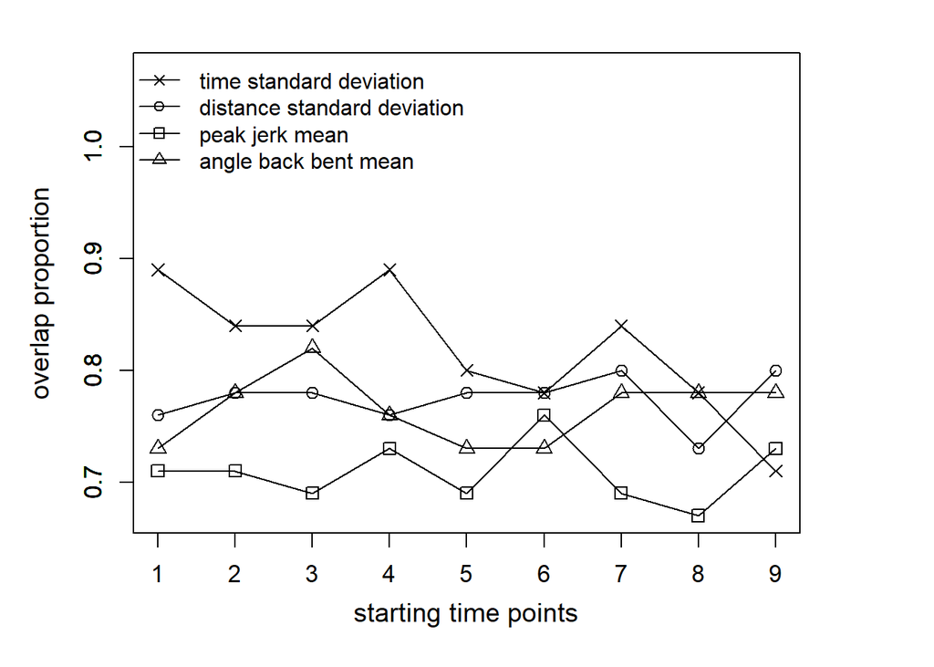

```r
data<-avg_table[,2:10]
Y_label<-"overlap proportion"
X_label<-"starting time points"

  clusters_data_clus1<-data[1,]
  clusters_data_clus2<-data[2,]
  clusters_data_clus3<-data[3,]
  clusters_data_clus4<-data[4,]

  clusters_data<-rbind(clusters_data_clus1,clusters_data_clus2,clusters_data_clus3,clusters_data_clus4)

  rownames(clusters_data)<-c("time standard deviation","distance standard deviation","peak jerk mean","angle back bent mean")
  miny<-min(clusters_data)
  maxy<-max(clusters_data)*1.2

  counter_years<-length(colnames(clusters_data))

  # mtext(side = 1, text = X_label, line = 2,cex=1.2)
  # mtext(side = 2, text = Y_label, line = 3,cex=1.2)

  par(mar = c(5,5,2,5),cex.lab=1.6)
  plot(as.numeric(clusters_data[1,]),xaxt="n", type="o", pch=4,col="black",ylim=c(miny,maxy),
      ann = FALSE, cex=1.2,cex.axis=1.1,lty=1,lwd = 1)
  line_dist<-4
  #next line is for tilted labels but for 2002-2016 I may deactive it

  axis(1,at=1:counter_years,labels=colnames(clusters_data),cex.axis=1.1,las=1)
  par(new = T)
  plot(as.numeric(clusters_data[2,]),xaxt="n", type="o", pch=1,col="black",ylim=c(miny,maxy),
       ann = FALSE, cex=1.2,cex.axis=1.1,lty=1,lwd = 1)
  par(new = T)
  plot(as.numeric(clusters_data[3,]),xaxt="n", type="o", pch=0,col="black",ylim=c(miny,maxy),
       ann = FALSE, cex=1.2,cex.axis=1.1,lty=1,lwd = 1)
  par(new = T)
  plot(as.numeric(clusters_data[4,]),xaxt="n", type="o", pch=2,col="black",ylim=c(miny,maxy),
       ann = FALSE, cex=1.2,cex.axis=1.1,lty=1,lwd = 1)

  mtext(side = 1, text = X_label, line = 2.5,cex=1.2)
  mtext(side = 2, text = Y_label, line = 3,cex=1.2)
  # axis(side = 4)
  # mtext(side = 4, line = 3, "Cluster 2")
  legend("topleft",
         legend=c("time standard deviation","distance standard deviation","peak jerk mean","angle back bent mean"),
                 lty=c(1,1,1,1), bty = "n",pch=c(4,1,0,2), col=c("black","black","black","black"),cex=1)
```

```r
####################
```

*the next table shows variance of the top 3 scenarios*

```r
DT::datatable(std_table)
```

|  | time | 1 | 2 | 3 | 4 | 5 | 6 | 7 | 8 | 9 | average |
| --- | --- | --- | --- | --- | --- | --- | --- | --- | --- | --- | --- |
| 1 | time standard deviation | 0.11 | 0.13 | 0.13 | 0.16 | 0.09 | 0.16 | 0.08 | 0.08 | 0.06 | 0.11 |
| 2 | distance standard deviation | 0.08 | 0.06 | 0.06 | 0.08 | 0.06 | 0.06 | 0.05 | 0.05 | 0.05 | 0.06 |
| 3 | peak jerk mean | 0.11 | 0.11 | 0.13 | 0.09 | 0.13 | 0.11 | 0.13 | 0.05 | 0.11 | 0.11 |
| 4 | angle back bent mean | 0 | 0.03 | 0.06 | 0.03 | 0 | 0 | 0.03 | 0.03 | 0.03 | 0.02 |

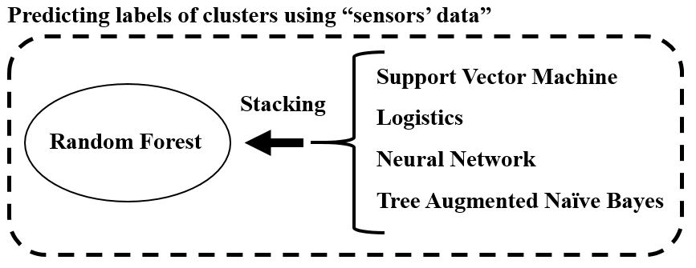

Prediction Methodology

```r
# in this section, I utilizes the top clustering methods (the one who had highest overlap between sensor data and borg) then use them for voting the cluster labels


  over_711_dis_par_top<-tail(data_obj[["t1_perf"]][order(data_obj$t1_perf$over_711),"dis_par"],top_alg)
  over_711_centr_par_top<-tail(data_obj[["t1_perf"]][order(data_obj$t1_perf$over_711),"centr_par"],top_alg)

  over_713_dis_par_top<-tail(data_obj[["t1_perf"]][order(data_obj$t1_perf$over_713),"dis_par"],top_alg)
  over_713_centr_par_top<-tail(data_obj[["t1_perf"]][order(data_obj$t1_perf$over_713),"centr_par"],top_alg)

  over_719_dis_par_top<-tail(data_obj[["t1_perf"]][order(data_obj$t1_perf$over_719),"dis_par"],top_alg)
  over_719_centr_par_top<-tail(data_obj[["t1_perf"]][order(data_obj$t1_perf$over_719),"centr_par"],top_alg)

  over_720_dis_par_top<-tail(data_obj[["t1_perf"]][order(data_obj$t1_perf$over_720),"dis_par"],top_alg)
  over_720_centr_par_top<-tail(data_obj[["t1_perf"]][order(data_obj$t1_perf$over_720),"centr_par"],top_alg)


  over_711_params_top<-paste(over_711_centr_par_top,"_",over_711_dis_par_top,sep="")
  over_713_params_top<-paste(over_713_centr_par_top,"_",over_713_dis_par_top,sep="")
  over_719_params_top<-paste(over_719_centr_par_top,"_",over_719_dis_par_top,sep="")
  over_720_params_top<-paste(over_720_centr_par_top,"_",over_720_dis_par_top,sep="")

  over_711_votes_top<-obj_1$clust_ID11[over_711_params_top]
  over_713_votes_top<-obj_1$clust_ID13[over_713_params_top]
  over_719_votes_top<-obj_1$clust_ID19[over_719_params_top]
  over_720_votes_top<-obj_1$clust_ID20[over_720_params_top]

  over_711_votes_top$major<-0
  over_713_votes_top$major<-0
  over_719_votes_top$major<-0
  over_720_votes_top$major<-0


  for(i in 1:15){
    over_711_votes_top$major[i]<-names(sort(table(as.numeric(over_711_votes_top[i,])),decreasing=TRUE))[1]
    over_713_votes_top$major[i]<-names(sort(table(as.numeric(over_713_votes_top[i,])),decreasing=TRUE))[1]
    over_719_votes_top$major[i]<-names(sort(table(as.numeric(over_719_votes_top[i,])),decreasing=TRUE))[1]
    over_720_votes_top$major[i]<-names(sort(table(as.numeric(over_720_votes_top[i,])),decreasing=TRUE))[1]
  }

  data_obj$pred<-list()
  data_obj$pred$data<-list()
  data_obj$pred$data$over_711_votes_top<-over_711_votes_top
  data_obj$pred$data$over_713_votes_top<-over_713_votes_top
  data_obj$pred$data$over_719_votes_top<-over_719_votes_top
  data_obj$pred$data$over_720_votes_top<-over_720_votes_top

  rm(list = c("over_711_dis_par_top","over_713_dis_par_top","over_719_dis_par_top","over_720_dis_par_top",
              "over_711_params_top","over_713_params_top","over_719_params_top","over_720_params_top",
              "over_711_votes_top","over_713_votes_top","over_719_votes_top","over_720_votes_top"))

  a11<-0
  a13<-0
  a19<-0
  a20<-0

  #after finding the label of targets based on majority voting, I add the physiological data

  set.seed(seed_no)
  # here I do regular prediction and then I try different ensembling for predicting clusters made through investigating step_time_SD
  # I first need to be sure if there are more than one member from each levels of the TARGET column
  if(!is.na((table(data_obj$pred$data$over_711_votes_top$major)[1]-1)*(table(data_obj$pred$data$over_711_votes_top$major)[2]-1))){
    a11<-1
  if((table(data_obj$pred$data$over_711_votes_top$major)[1]-1)*(table(data_obj$pred$data$over_711_votes_top$major)[2]-1)>0){
    a11<-2
  data_obj$pred$data$pred_711<-obj_1$data_table_ID3.4.5.6
  names(data_obj$pred$data$pred_711)<-c("ID","gender", "age", "weight", "height")
  data_obj$pred$data$pred_711$TARGET<-as.numeric(data_obj$pred$data$over_711_votes_top$major)-1

  #first, I do simple leave-out prediction.
  #data: data used in the prediction
  #TARGET: target variable
  #vars<- independent variables
  #ensembler: super learning algorithm in ensembling approach
  #B_alg: sample balancing algorithm (RUS,SMOTE,NONE)
  #cntr_type:specifying "trainControl" in the caret package, for more information check inside of the "leave_out" function
  #method_pred: specifying if it is a regular preduction or an ensemble one

  data_obj$pred$regular_pred11<-leave_out(data<-data_obj$pred$data$pred_711,TARGET<-"TARGET",vars<-c( "gender", "age", "weight", "height") ,ensembler<-"none",
                            B_alg<-"none",cntr_type<-"simple",method_pred<-"regular")

  data_obj$pred$ensemble_pred11<-list()
  # data_obj$pred$ensemble_pred11$ensemble_svm11<-leave_out(data_obj$pred$regular_pred11$resul_prob,"TARGET",c("log", "rf" ,"nnet","tan") ,"svm_ens","none","simple","ensemble")
  data_obj$pred$ensemble_pred11$ensemble_log11<-leave_out(data_obj$pred$regular_pred11$resul_prob,"TARGET",c("svm", "rf" ,"nnet","tan") ,"log_ens","none","simple","ensemble")
  data_obj$pred$ensemble_pred11$ensemble_rf11<-leave_out(data_obj$pred$regular_pred11$resul_prob,"TARGET",c("log", "svm" ,"nnet","tan") ,"rf_ens","none","simple","ensemble")
  data_obj$pred$ensemble_pred11$ensemble_nnet11<-leave_out(data_obj$pred$regular_pred11$resul_prob,"TARGET",c("log", "svm" ,"rf","tan") ,"nnet_ens","none","simple","ensemble")
  }
  }
  # end of the prediction


  set.seed(seed_no)
  # here I do regular prediction and then I try different ensembling for predicting clusters made through investigating step_distance_SD
  # I first need to be sure if there are more than one member from each levels of the TARGET column
  if(!is.na((table(data_obj$pred$data$over_713_votes_top$major)[1]-1)*(table(data_obj$pred$data$over_713_votes_top$major)[2]-1))){
    a13<-1
  if((table(data_obj$pred$data$over_713_votes_top$major)[1]-1)*(table(data_obj$pred$data$over_713_votes_top$major)[2]-1)>0){
    a13<-2
    data_obj$pred$data$pred_713<-obj_1$data_table_ID3.4.5.6
    names(data_obj$pred$data$pred_713)<-c("ID","gender", "age", "weight", "height")
    data_obj$pred$data$pred_713$TARGET<-as.numeric(data_obj$pred$data$over_713_votes_top$major)-1

    #first, I do simple leave-out prediction.
    #data: data used in the prediction
    #TARGET: target variable
    #vars<- independent variables
    #ensembler: super learning algorithm in ensembling approach
    #B_alg: sample balancing algorithm (RUS,SMOTE,NONE)
    #cntr_type:specifying "trainControl" in the caret package, for more information check inside of the "leave_out" function
    #method_pred: specifying if it is a regular preduction or an ensemble one
```

```r
    data_obj$pred$regular_pred13<-leave_out(data<-data_obj$pred$data$pred_713,TARGET<-"TARGET",vars<-c( "gender", "age", "weight", "height") ,ensembler<-"none",
                                            B_alg<-"none",cntr_type<-"simple",method_pred<-"regular")

    data_obj$pred$ensemble_pred13<-list()

    # data_obj$pred$ensemble_pred13$ensemble_svm13<-leave_out(data_obj$pred$regular_pred13$resul_prob,"TARGET",c("log", "rf" ,"nnet","tan") ,"svm_ens","none","simple","ensemble")
    data_obj$pred$ensemble_pred13$ensemble_log13<-leave_out(data_obj$pred$regular_pred13$resul_prob,"TARGET",c("svm", "rf" ,"nnet","tan") ,"log_ens","none","simple","ensemble")
    data_obj$pred$ensemble_pred13$ensemble_rf13<-leave_out(data_obj$pred$regular_pred13$resul_prob,"TARGET",c("log", "svm" ,"nnet","tan") ,"rf_ens","none","simple","ensemble")
    data_obj$pred$ensemble_pred13$ensemble_nnet13<-leave_out(data_obj$pred$regular_pred13$resul_prob,"TARGET",c("log", "svm" ,"rf","tan") ,"nnet_ens","none","simple","ensemble")
   }
  }
  # end of the prediction


  set.seed(seed_no)
  # here I do regular prediction and then I try different ensembling for predicting clusters made through investigating step_peak_jrk_average
  # I first need to be sure if there are more than one member from each levels of the TARGET column
    if(!is.na((table(data_obj$pred$data$over_719_votes_top$major)[1]-1)*(table(data_obj$pred$data$over_719_votes_top$major)[2]-1))){
      a19<-1
    if((table(data_obj$pred$data$over_719_votes_top$major)[1]-1)*(table(data_obj$pred$data$over_719_votes_top$major)[2]-1)>0){
    a19<-2
    data_obj$pred$data$pred_719<-obj_1$data_table_ID3.4.5.6
    names(data_obj$pred$data$pred_719)<-c("ID","gender", "age", "weight", "height")
    data_obj$pred$data$pred_719$TARGET<-as.numeric(data_obj$pred$data$over_719_votes_top$major)-1

    #first, I do simple leave-out prediction.
    #data: data used in the prediction
    #TARGET: target variable
    #vars<- independent variables
    #ensembler: super learning algorithm in ensembling approach
    #B_alg: sample balancing algorithm (RUS,SMOTE,NONE)
    #cntr_type:specifying "trainControl" in the caret package, for more information check inside of the "leave_out" function
    #method_pred: specifying if it is a regular preduction or an ensemble one

    data_obj$pred$regular_pred19<-leave_out(data<-data_obj$pred$data$pred_719,TARGET<-"TARGET",vars<-c( "gender", "age", "weight", "height") ,ensembler<-"none",
                                            B_alg<-"none",cntr_type<-"simple",method_pred<-"regular")

    data_obj$pred$ensemble_pred19<-list()
    # data_obj$pred$ensemble_pred19$ensemble_svm19<-leave_out(data_obj$pred$regular_pred19$resul_prob,"TARGET",c("log", "rf" ,"nnet","tan") ,"svm_ens","none","simple","ensemble")
    data_obj$pred$ensemble_pred19$ensemble_log19<-leave_out(data_obj$pred$regular_pred19$resul_prob,"TARGET",c("svm", "rf" ,"nnet","tan") ,"log_ens","none","simple","ensemble")
    data_obj$pred$ensemble_pred19$ensemble_rf19<-leave_out(data_obj$pred$regular_pred19$resul_prob,"TARGET",c("log", "svm" ,"nnet","tan") ,"rf_ens","none","simple","ensemble")
    data_obj$pred$ensemble_pred19$ensemble_nnet19<-leave_out(data_obj$pred$regular_pred19$resul_prob,"TARGET",c("log", "svm" ,"rf","tan") ,"nnet_ens","none","simple","ensemble")
    }
  }
  # end of the prediction



   set.seed(seed_no)
  # here I do regular prediction and then I try different ensembling for predicting clusters made through investigating step_peak_jrk_average
  # I first need to be sure if there are more than one member from each levels of the TARGET column
  if(!is.na((table(data_obj$pred$data$over_720_votes_top$major)[1]-1)*(table(data_obj$pred$data$over_720_votes_top$major)[2]-1))){
    a20<-1
  if((table(data_obj$pred$data$over_720_votes_top$major)[1]-1)*(table(data_obj$pred$data$over_720_votes_top$major)[2]-1)>0){
    a20<-2
    data_obj$pred$data$pred_720<-obj_1$data_table_ID3.4.5.6
    names(data_obj$pred$data$pred_720)<-c("ID","gender", "age", "weight", "height")
    data_obj$pred$data$pred_720$TARGET<-as.numeric(data_obj$pred$data$over_720_votes_top$major)-1

    #first, I do simple leave-out prediction.
    #data: data used in the prediction
    #TARGET: target variable
    #vars<- independent variables
    #ensembler: super learning algorithm in ensembling approach
    #B_alg: sample balancing algorithm (RUS,SMOTE,NONE)
    #cntr_type:specifying "trainControl" in the caret package, for more information check inside of the "leave_out" function
    #method_pred: specifying if it is a regular preduction or an ensemble one

    data_obj$pred$regular_pred20<-leave_out(data<-data_obj$pred$data$pred_720,TARGET<-"TARGET",vars<-c( "gender", "age", "weight", "height") ,ensembler<-"none",
                                            B_alg<-"none",cntr_type<-"simple",method_pred<-"regular")

    data_obj$pred$ensemble_pred20<-list()
    # data_obj$pred$ensemble_pred20$ensemble_svm20<-leave_out(data_obj$pred$regular_pred20$resul_prob,"TARGET",c("log", "rf" ,"nnet","tan") ,"svm_ens","none","simple","ensemble")
    data_obj$pred$ensemble_pred20$ensemble_log20<-leave_out(data_obj$pred$regular_pred20$resul_prob,"TARGET",c("svm", "rf" ,"nnet","tan") ,"log_ens","none","simple","ensemble")
    data_obj$pred$ensemble_pred20$ensemble_rf20<-leave_out(data_obj$pred$regular_pred20$resul_prob,"TARGET",c("log", "svm" ,"nnet","tan") ,"rf_ens","none","simple","ensemble")
    data_obj$pred$ensemble_pred20$ensemble_nnet20<-leave_out(data_obj$pred$regular_pred20$resul_prob,"TARGET",c("log", "svm" ,"rf","tan") ,"nnet_ens","none","simple","ensemble")
  }
  }

  # end of the prediction
  save(data_obj,file=paste(getwd(),"/","IoT_object_seed_",seed_no,"_votes_",top_alg,".RData",sep=""))
```

the next table shows labels of top 3 clustering algorithm which over lap of step_time_SD and Borg’s rate was the highest. In the major column, the cluster label is assigned based on majority of votes in the algorithms. column names’ format represent parameters of clustering algorithm and is as: “centroid parameter”_“distance parameter”

```r
  DT::datatable(data_obj$pred$data$over_711_votes_top)
```

|  | shape_lbi | mean_sbd | shape_dtw2 | major |
| --- | --- | --- | --- | --- |
| 1 | 2 | 1 | 2 | 2 |
| 2 | 2 | 1 | 2 | 2 |
| 3 | 2 | 2 | 2 | 2 |
| 4 | 1 | 1 | 2 | 1 |
| 5 | 2 | 1 | 2 | 2 |
| 6 | 1 | 1 | 1 | 1 |
| 7 | 1 | 1 | 2 | 1 |
| 8 | 2 | 1 | 2 | 2 |
| 9 | 2 | 1 | 2 | 2 |
| 10 | 1 | 1 | 2 | 1 |

[output cut: 5 more lines]

the next table shows performance of machine learning algorithms in predictive labels of clusters in the previous table

```r
    if(!is.null(data_obj$pred$regular_pred11$performance)){
  DT::datatable(data_obj$pred$regular_pred11$performance)}else{cat("at least one of the cluster categories dosn't have more than one  subjeccts")}
```

|  | accuracy | sensitivity | specificity | auc |
| --- | --- | --- | --- | --- |
| log | 0.6 | 0.4 | 0.7 | 0.46 |
| rf | 0.93 | 0.8 | 1 | 0.9 |
| nnet | 0.6 | 0.2 | 0.8 | 0.62 |
| svm | 0.67 | 0 | 1 | 1 |
| tan | 0.73 | 0.4 | 0.9 | 0.7 |

For improving performance of prediction, I adopted random Forest Ensembler as the super learner (and output of other models as inputs) over the previous machine learning algorithms and the results are demonstrated below:

```r
   if(!is.null(data_obj$pred$ensemble_pred11$ensemble_rf11$performance)){
 DT::datatable(data_obj$pred$ensemble_pred11$ensemble_rf11$performance)}else{cat("at least one of the cluster categories dosn't have more than one  subjeccts")}
```

|  | accuracy | sensitivity | specificity | auc |
| --- | --- | --- | --- | --- |
| ensemble_rf_ens | 1 | 1 | 1 | 1 |

the next table shows labels of top 3 clustering algorithm which over lap of step_distance_SD and Borg’s rate was the highest. In the major column, the cluster label is assigned based on majority of votes in the algorithms. column names’ format represent parameters of clustering algorithm and is as: “centroid parameter”_“distance parameter”

```r
  DT::datatable(data_obj$pred$data$over_713_votes_top)
```

|  | shape_lbi | pam_sdtw | dba_sbd | major |
| --- | --- | --- | --- | --- |
| 1 | 2 | 2 | 2 | 2 |
| 2 | 2 | 2 | 2 | 2 |
| 3 | 1 | 1 | 1 | 1 |
| 4 | 1 | 2 | 2 | 2 |
| 5 | 2 | 2 | 2 | 2 |
| 6 | 2 | 2 | 2 | 2 |
| 7 | 2 | 2 | 2 | 2 |
| 8 | 2 | 2 | 2 | 2 |
| 9 | 1 | 2 | 2 | 2 |
| 10 | 2 | 2 | 2 | 2 |

[output cut: 5 more lines]

the next table shows performance of machine learning algorithms in predictive labels of clusters in the previous table

```r
    if(!is.null(data_obj$pred$regular_pred13$performance)){
  DT::datatable(data_obj$pred$regular_pred13$performance)
}else{cat("at least one of the cluster categories dosn't have more than one  subjeccts")}
```

```
## at least one of the cluster categories dosn't have more than one  subjeccts
```

For improving performance of prediction, I adopted random Forest Ensembler as the super learner (and output of other models as inputs) over the previous machine learning algorithms and the results are demonstrated below:

```r
   if(!is.null(data_obj$pred$ensemble_pred13$ensemble_rf13$performance)){
 DT::datatable(data_obj$pred$ensemble_pred13$ensemble_rf13$performance)}else{cat("at least one of the cluster categories dosn't have more than one  subjeccts")}
```

```
## at least one of the cluster categories dosn't have more than one  subjeccts
```

the next table shows labels of top 3 clustering algorithm which over lap of step_peak_jrk_average and Borg’s rate was the highest. In the major column, the cluster label is assigned based on majority of votes in the algorithms. column names’ format represent parameters of clustering algorithm and is as: “centroid parameter”_“distance parameter”

```r
  DT::datatable(data_obj$pred$data$over_719_votes_top)
```

|  | pam_dtw_lb | dba_sdtw | dba_sbd | major |
| --- | --- | --- | --- | --- |
| 1 | 2 | 2 | 2 | 2 |
| 2 | 2 | 2 | 2 | 2 |
| 3 | 2 | 1 | 1 | 1 |
| 4 | 2 | 2 | 2 | 2 |
| 5 | 2 | 2 | 2 | 2 |
| 6 | 1 | 1 | 2 | 1 |
| 7 | 2 | 2 | 2 | 2 |
| 8 | 2 | 2 | 2 | 2 |
| 9 | 2 | 2 | 2 | 2 |
| 10 | 2 | 2 | 2 | 2 |

[output cut: 5 more lines]

the next table shows performance of machine learning algorithms in predictive labels of clusters in the previous table

```r
    if(!is.null(data_obj$pred$regular_pred19$performance)){
  DT::datatable(data_obj$pred$regular_pred19$performance)}else{cat("at least one of the cluster categories dosn't have more than one  subjeccts")}
```

|  | accuracy | sensitivity | specificity | auc |
| --- | --- | --- | --- | --- |
| log | 0.6 | 0 | 0.82 | 0.8 |
| rf | 0.53 | 0 | 0.73 | 0.86 |
| nnet | 0.6 | 0 | 0.82 | 0.89 |
| svm | 0.73 | 0 | 1 | 1 |
| tan | 0.6 | 0 | 0.82 | 1 |

For improving performance of prediction, I adopted random Forest Ensembler as the super learner (and output of other models as inputs) over the previous machine learning algorithms and the results are demonstrated below:

```r
   if(!is.null(data_obj$pred$ensemble_pred19$ensemble_rf19$performance)){
 DT::datatable(data_obj$pred$ensemble_pred19$ensemble_rf19$performance)}else{cat("at least one of the cluster categories dosn't have more than one  subjeccts")}
```

|  | accuracy | sensitivity | specificity | auc |
| --- | --- | --- | --- | --- |
| ensemble_rf_ens | 1 | 1 | 1 | 1 |

the next table shows labels of top 3 clustering algorithm which over lap of overall_average_angle_back_bent and Borg’s rate was the highest. In the major column, the cluster label is assigned based on majority of votes in the algorithms. column names’ format represent parameters of clustering algorithm and is as: “centroid parameter”_“distance parameter”

```r
  DT::datatable(data_obj$pred$data$over_720_votes_top)
```

|  | dba_gak | pam_gak | pam_sdtw | major |
| --- | --- | --- | --- | --- |
| 1 | 2 | 2 | 2 | 2 |
| 2 | 1 | 1 | 1 | 1 |
| 3 | 2 | 2 | 2 | 2 |
| 4 | 2 | 2 | 2 | 2 |
| 5 | 2 | 2 | 2 | 2 |
| 6 | 1 | 1 | 1 | 1 |
| 7 | 2 | 2 | 2 | 2 |
| 8 | 1 | 1 | 1 | 1 |
| 9 | 2 | 2 | 2 | 2 |
| 10 | 1 | 1 | 1 | 1 |

[output cut: 5 more lines]

the next table shows performance of machine learning algorithms in predictive labels of clusters in the previous table

```r
    if(!is.null(data_obj$pred$regular_pred20$performance)){
  DT::datatable(data_obj$pred$regular_pred20$performance)}else{cat("at least one of the cluster categories dosn't have more than one  subjeccts")}
```

|  | accuracy | sensitivity | specificity | auc |
| --- | --- | --- | --- | --- |
| log | 0.47 | 0.2 | 0.6 | 0.48 |
| rf | 0.53 | 0.2 | 0.7 | 0.74 |
| nnet | 0.53 | 0.4 | 0.6 | 0.5 |
| svm | 0.67 | 0 | 1 | 1 |
| tan | 0.4 | 0 | 0.6 | 0.82 |

For improving performance of prediction, I adopted random Forest Ensembler as the super learner (and output of other models as inputs) over the previous machine learning algorithms and the results are demonstrated below:

```r
   if(!is.null(data_obj$pred$ensemble_pred20$ensemble_rf20$performance)){
 DT::datatable(data_obj$pred$ensemble_pred20$ensemble_rf20$performance)}else{cat("at least one of the cluster categories dosn't have more than one  subjeccts")}
```

|  | accuracy | sensitivity | specificity | auc |
| --- | --- | --- | --- | --- |
| ensemble_rf_ens | 1 | 1 | 1 | 1 |

[^1]: Aubrun University, azg0074@auburn.edu
[^2]: Miami University, fmegahed@miamioh.edu
[^3]: University of Buffalo, loracavu@buffalo.edu
[^4]: Aubrun University, hamid@auburn.edu